# Part II - Ford GoBike Exploration

## Investigation Overview

> My interest is to know where and when most trips are taken in terms of the hour of the day or day of the week and differ between Customers and Subscribers. The characteristics include rider's attributes (sex, age, and user_type) and duration of trips.

## Dataset Overview

> This data set includes information about individual rides made in a bike-sharing system covering the greater San Francisco Bay area. it is downloaded from **[Udacity](http://https://video.udacity-data.com/topher/2020/October/5f91cf38_201902-fordgobike-tripdata/201902-fordgobike-tripdata.csv)** This dataset includes 183412 trips with 16 features such as locations, time, and user attributes. There are start and end stations.

```python
# import all packages and set plots to be embedded inline
import numpy as np
import pandas as pd
import matplotlib.pyplot as plt
import seaborn as sb

%matplotlib inline

# suppress warnings from final output
import warnings
warnings.simplefilter("ignore")
```

```python
# load in the dataset into a pandas dataframe
gobikes = pd.read_csv('fordgobikes-tripdata_clean.csv')
```

```python
df_cust = gobikes.query('user_type == "Customer"')
df_sub = gobikes.query('user_type == "Subscriber"')
```

# Key derived insights

## Distribution of usertype

> The majority of the bikers are subscribers.

[figure not shown]

```python
# to identify the distribution of user type.
labels = list(gobikes.user_type.unique())
sizes = gobikes.user_type.value_counts()
explode = (0.16, 0)

fig1, ax1 = plt.subplots()
ax1.pie(sizes, labels=labels, autopct='%1.1f%%',
        shadow=True, startangle=90 , explode = explode )

ax1.axis('equal')
plt.tight_layout()
plt.title('User type distribution')
plt.show()
```

## Distribution of member gender

> Male users are more than the female users

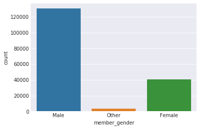

```python
# count of member gender
sb.countplot(data=gobikes,x='member_gender');
```

## Distribution of users age

> The mode is 34 and the mean is 37.2.

I already assumed the young users will be more than the old users and this has confirmed it.

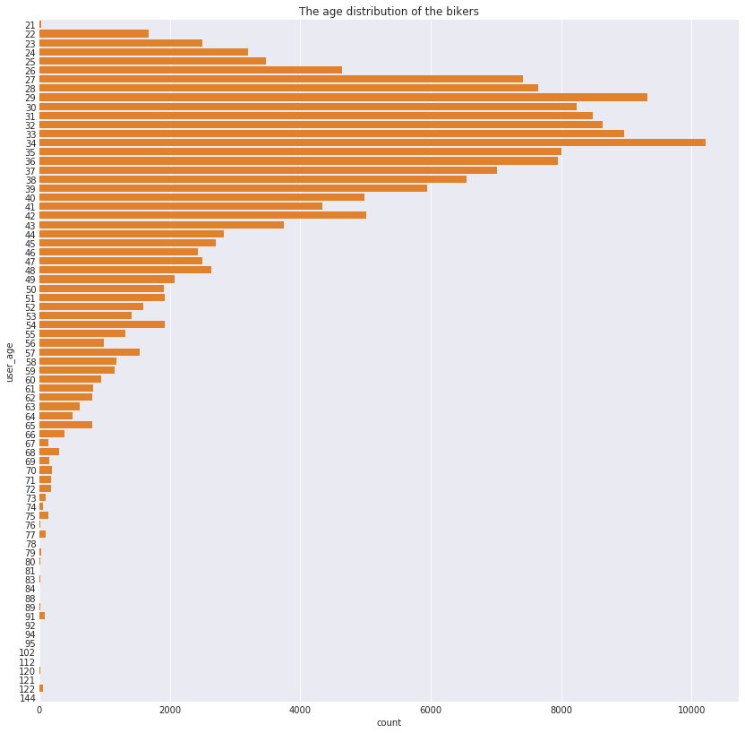

```
0    34
dtype: int64
37.1968654259
```

```python
# To identify the distribution of bikers ages.

base_color = sb.color_palette()[1]
plt.figure(figsize=[14, 14])

ax = sb.countplot(data = gobikes, y = 'user_age', color = base_color)
# Set title
ax.set_title("The age distribution of the bikers")
plt.show()
print(gobikes.user_age.mode())
print(gobikes.user_age.mean())
```

## The top 10 stations with the most trips

> Market St at 10th St and San Francisco Caltrain Station 2 (Townsend St at 4th St) are the most popular start points

```python
# I subset the dataset by keeping only top 10 locations with high traffics, df_top10.
locs = ['Market St at 10th St','San Francisco Caltrain Station 2  (Townsend St at 4th St)','Berry St at 4th St','Montgomery St BART Station (Market St at 2nd St)','Powell St BART Station (Market St at 4th St)','San Francisco Caltrain (Townsend St at 4th St)','San Francisco Ferry Building (Harry Bridges Plaza)','Howard St at Beale St', 'Steuart St at Market St', 'Powell St BART Station (Market St at 5th St)']
df_top10 = gobikes.loc[gobikes['start_station_name'].isin(locs)]
```

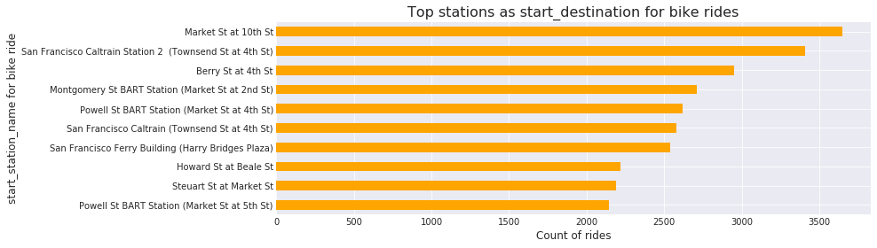

```python
# Top 10 start station name for bike ride
plt.figure(figsize=(12,4))
sb.set_style('darkgrid')
df_top10['start_station_name'].value_counts().sort_values(ascending=True).plot(kind='barh', color='orange');
plt.title('Top stations as start_destination for bike rides', fontsize=16)
plt.xlabel('Count of rides', fontsize=12)
plt.ylabel('start_station_name for bike ride', fontsize=12);
```

## The top 10 stations with the most trips

> San Francisco Caltrain Station 2 (Townsend St at 4th St) and Market St at 10th St are the most popular destinations.

```python
# let us limit to the top 10 destinations:
top_dest = gobikes['end_station_name'].value_counts().index[:10]
```

```python
# here we create dataframe with trips only to top 10 destinations
top_dest_df = gobikes.loc[gobikes['end_station_name'].isin(top_dest)]
```

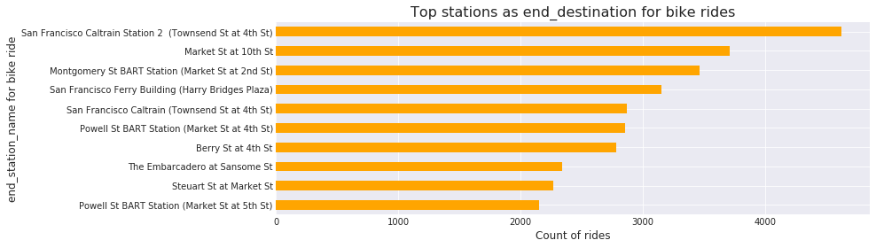

```python
# Top 10 end station name for bike ride
plt.figure(figsize=(12,4))
sb.set_style('darkgrid')
top_dest_df['end_station_name'].value_counts().sort_values(ascending=True).plot(kind='barh', color='orange');
plt.title('Top stations as end_destination for bike rides', fontsize=16)
plt.xlabel('Count of rides', fontsize=12)
plt.ylabel('end_station_name for bike ride', fontsize=12);
```

## Relationship between trip duration and users gender

> Females stay longer on the bikes than males

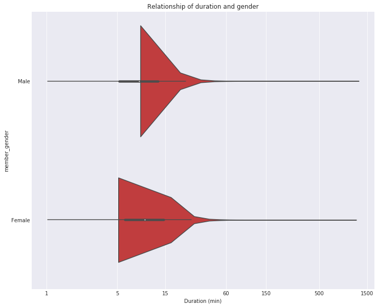

```python
#I use large sample size to further interpret the plot.
#Sample of 100k values.
log_binsize = 0.025
bins = 10 ** np.arange(2.4, np.log10(gobikes['duration_min'].max())+log_binsize, log_binsize)
plt.figure(figsize=(12,10))
samples = np.random.choice(gobikes.shape[0], 100000, replace = False);
bike_samp = gobikes.iloc[samples,:];
base_color = sb.color_palette()[3]
plt.xscale('log')
sb.violinplot(data = bike_samp[bike_samp['member_gender'] != "Other"] , y = 'member_gender', x = 'duration_min', color = base_color )
plt.xlabel('Duration (min)')
plt.title('Relationship of duration and gender')
plt.xticks([1, 5, 15 , 60 , 150 , 500 , 1500] , [1, 5, 15 , 60 , 150 , 500 , 1500])
plt.show()
```

## Trip duration per user type

> the subscribers have more bike trips because there are more subscribers than customers.

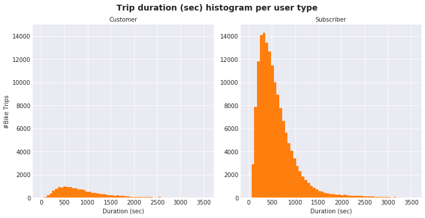

```python
# Duration (sec) distribution per user type

g = sb.FacetGrid(gobikes, col="user_type", margin_titles=True, size=5)
bin_edges = np.arange(0, 3600,60)
g.map(plt.hist, "duration_sec", color=sb.color_palette()[1], bins=bin_edges)
g.set_axis_labels("Duration (sec)", "#Bike Trips")
g.set_titles(col_template = '{col_name}')
g.fig.suptitle('Trip duration (sec) histogram per user type', y=1.03, fontsize=14, fontweight='semibold');
```

## The time with most trips

> There are the most trips in the morning. There are the most trips during the weekdays than the weekends.

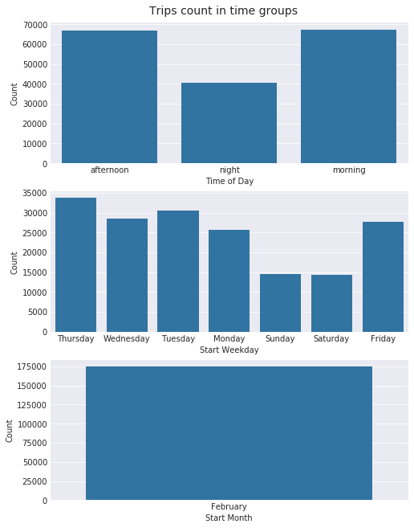

```python
fig, ax = plt.subplots(nrows=3, figsize = [8,10])
default_color = sb.color_palette()[0]
sb.countplot(data = gobikes, x = 'period_day', color = default_color, ax = ax[0])
sb.countplot(data = gobikes, x = 'start_weekday', color = default_color, ax = ax[1])
sb.countplot(data = gobikes, x = 'start_month', color = default_color, ax = ax[2])
ax[0].set_xlabel('Time of Day')
ax[0].set_ylabel('Count')
ax[1].set_xlabel('Start Weekday')
ax[1].set_ylabel('Count')
ax[2].set_xlabel('Start Month')
ax[2].set_ylabel('Count')
plt.subplots_adjust(top=0.95)
fig.suptitle('Trips count in time groups', fontsize=14);
```

## Hourly usage varies during a week for Customers and Subscribers?

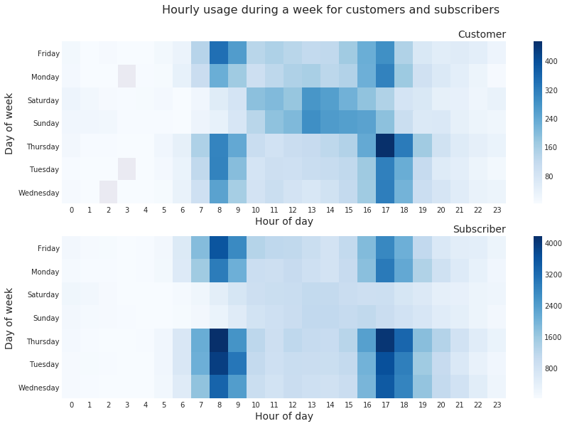

```python
# Hourly usage varies during a week for Customers and Subscribers

plt.figure(figsize=(14,9))

plt.subplot(2, 1, 1)
customers = gobikes.query('user_type == "Customer"')
ct_counts = customers.groupby(['start_weekday', 'start_hour']).size()
ct_counts = ct_counts.reset_index(name='count')
ct_counts = ct_counts.pivot(index='start_weekday', columns='start_hour', values='count')
sb.heatmap(ct_counts, cmap="Blues");
plt.title('Customer', loc='right', fontsize=14);
plt.xlabel('Hour of day', fontsize=14);
plt.ylabel('Day of week', fontsize=14);

plt.subplot(2, 1, 2)
subscribers = gobikes.query('user_type == "Subscriber"')
st_counts = subscribers.groupby(['start_weekday', 'start_hour']).size()
st_counts = st_counts.reset_index(name='count')
st_counts = st_counts.pivot(index='start_weekday', columns='start_hour', values='count')
sb.heatmap(st_counts, cmap="Blues");
plt.title('Subscriber', loc='right', fontsize=14);
plt.xlabel('Hour of day', fontsize=14);
plt.ylabel('Day of week', fontsize=14);

plt.subplots_adjust(top=0.9)
plt.suptitle('Hourly usage during a week for customers and subscribers', fontsize=16);
```

## Distribution of trip duration over respectively start_day_of_week and top destination end_station_name

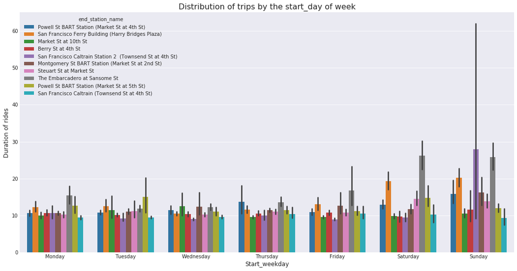

```python
plt.figure(figsize=(18,9))
base_color = sb.color_palette()[1]

weekday = ['Monday', 'Tuesday', 'Wednesday', 'Thursday', 'Friday', 'Saturday', 'Sunday']
weekdaycat = pd.api.types.CategoricalDtype(ordered=True, categories=weekday)
top_dest_df['start_weekday'] = top_dest_df['start_weekday'].astype(weekdaycat)

sb.barplot(data=top_dest_df, x='start_weekday', y='duration_min', hue='end_station_name')
plt.xlabel('Start_weekday', fontsize=12)
plt.ylabel('Duration of rides', fontsize=12)
plt.title("Distribution of trips by the start_day of week", fontsize=16);
```

[figure not shown]

```python
plt.figure(figsize=(15,9))
base_color = sb.color_palette()[1]

weekday = ['Monday', 'Tuesday', 'Wednesday', 'Thursday', 'Friday', 'Saturday', 'Sunday']
weekdaycat = pd.api.types.CategoricalDtype(ordered=True, categories=weekday)
top_dest_df['start_weekday'] = top_dest_df['start_weekday'].astype(weekdaycat)

sb.barplot(data=top_dest_df, y='end_station_name', x='duration_min', hue='user_type')
plt.xlabel('Start day of week', fontsize=15)
plt.ylabel('Duration of rides', fontsize=15)
plt.title("Distribution of trips by the start_day of week", fontsize=16);
```

[figure not shown]

```python
from IPython.display import Image
Image(filename='Sansome.png')
```

```python
# Use this command if you are running this file in local
!jupyter nbconvert <Slidedeck_fordgobikes.ipynb>.ipynb --to slides --post serve --no-input --no-prompt
```